# Assignment 1

Jonathan Lee

September 16, 2020

I used the Wes Anderson color package.

```r
# install.packages("wesanderson")
```

## Data Gathering and Cleanup.

### I mostly used the Los Angeles County tract-level data but also used the aggregated county-level data for a couple figures.

```r
library(tidycensus)
library(tidyverse)
library(magrittr)
library(scales)
library(wesanderson)

vars <- c(tot_hh = "B11009_001",
          tot_unmarried_hh = "B11009_002",
          mm_hh = "B11009_003",
          mf_hh = "B11009_004",
          ff_hh = "B11009_005",
          fm_hh = "B11009_006",
          other_hh = "B11009_007",
          med_income = "B19013_001",
          tot_housing = "B25008_001",
          owned_housing = "B25008_002",
          rented_housing = "B25008_003",
          edu_tot = "B06009_001",
          edu_less_hs = "B06009_002",
          edu_hs = "B06009_003",
          edu_some_college = "B06009_004",
          edu_bach = "B06009_005",
          edu_grad = "B06009_006")

LA_tracts <- get_acs(geography = "tract",
                            variables = vars,
                            year = 2018, state = "CA",
                            county = "Los Angeles",
                            output = "wide") %>%
            rename(tot_hh = tot_hhE,
                   tot_unmarried_hh = tot_unmarried_hhE,
                   mm_hh = mm_hhE,
                   mf_hh = mf_hhE,
                   ff_hh = ff_hhE,
                   fm_hh = fm_hhE,
                   other_hh = other_hhE,
                   med_income = med_incomeE,
                   tot_housing = tot_housingE,
                   owned_housing = owned_housingE,
                   rented_housing = rented_housingE,
                   edu_tot = edu_totE,
                   edu_less_hs = edu_less_hsE,
                   edu_hs = edu_hsE,
                   edu_some_college = edu_some_collegeE,
                   edu_bach = edu_bachE,
                   edu_grad = edu_gradE) %>%
            mutate(samesex_hh_exist = case_when(
                                  mm_hh != 0 ~ TRUE,
                                  ff_hh != 0 ~ TRUE,
                                  TRUE ~ FALSE),
                   inc_abo_50 = case_when(
                     med_income >= 50000 ~ TRUE,
                     TRUE ~ FALSE),
                    pct_samesex_hh = (mm_hh+ff_hh)/tot_unmarried_hh,
                    pct_rented = rented_housing/tot_housing,
                    pct_edu_less_hs = edu_less_hs/edu_tot)%>%
            filter(tot_hh > 0, edu_tot > 0, tot_housing > 0) %>%
            select(GEOID, tot_hh, tot_unmarried_hh, mm_hh, mf_hh, ff_hh, fm_hh,
                   other_hh,samesex_hh_exist, pct_samesex_hh, med_income,
                   inc_abo_50, tot_housing, owned_housing, rented_housing, pct_rented,
                   edu_tot, edu_less_hs, edu_hs, edu_some_college, edu_bach, edu_grad,
                   pct_edu_less_hs)


LA_county <- get_acs(geography = "county",
                            variables = vars,
                            year = 2018, state = "CA",
                            county = "Los Angeles",
                            output = "wide")%>%
            rename(tot_hh = tot_hhE,
                   tot_unmarried_hh = tot_unmarried_hhE,
                   mm_hh = mm_hhE,
                   mf_hh = mf_hhE,
                   ff_hh = ff_hhE,
                   fm_hh = fm_hhE,
                   other_hh = other_hhE,
                   med_income = med_incomeE,
                   tot_housing = tot_housingE,
                   owned_housing = owned_housingE,
                   rented_housing = rented_housingE)
```

## Plot #1

### The total number of households in Los Angeles County and the number of households with unmarried couples.

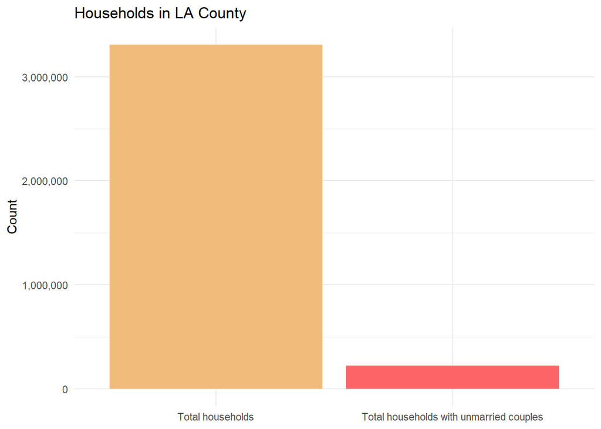

```r
LA_county_pivot_1 <- LA_county %>%
                    pivot_longer(c( tot_hh, tot_unmarried_hh),
                           names_to = "total_hh_type", values_to = "count")

ggplot(
  LA_county_pivot_1,
  aes(x = total_hh_type, y = count, fill = total_hh_type)) +

  geom_col() +
  labs(title = "Households in LA County") +
  ylab("Count")+
  xlab(NULL)+
  scale_x_discrete(labels = c("tot_hh" = "Total households",
                              "tot_unmarried_hh" = "Total households with unmarried couples"))+
  scale_y_continuous(labels = comma)+
  theme_minimal()+
  theme(legend.position = 'none')+
  scale_fill_manual(values = wes_palette("GrandBudapest1"))
```

## Plot #2

### The breakdown of the unmarried couple households into type by genders of the couple.

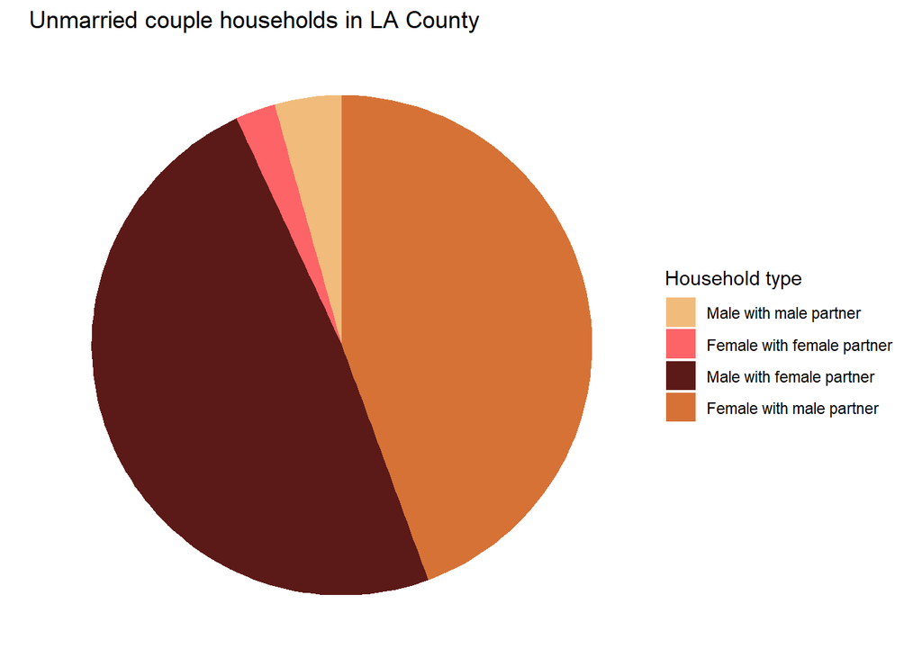

```r
LA_county_pivot_2 <- LA_county %>%
                    pivot_longer(c( mm_hh,ff_hh, mf_hh, fm_hh),
                           names_to = "hh_type", values_to = "count")

ggplot(
  LA_county_pivot_2,
   aes(x = 1, y = count, fill = factor(hh_type, levels=c("mm_hh", "ff_hh","mf_hh","fm_hh")))) +

  geom_col(position = "fill") +
  labs(title = "Unmarried couple households in LA County") +

  coord_polar("y", start = 0) +
  scale_fill_manual(name = "Household type",
                      labels = c("Male with male partner", "Female with female partner",
                                 "Male with female partner", "Female with male partner"),
                      values = wes_palette("GrandBudapest1"))+
  theme_void()
```

## Plot #3

### Tracts with reported same-sex unmarried couples and their median income distribution.

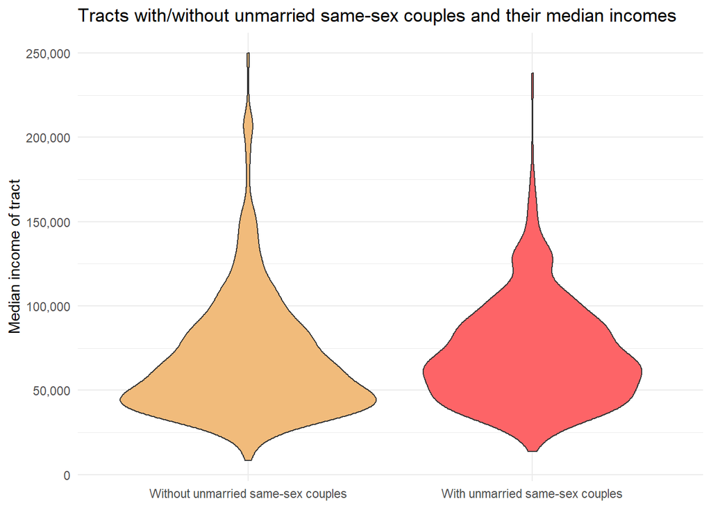

```r
ggplot(
  LA_tracts %>% drop_na(med_income),
  aes(x = samesex_hh_exist, y = med_income, fill = samesex_hh_exist)) +

  geom_violin() +
  labs(title = "Tracts with/without unmarried same-sex couples and their median incomes") +
  ylab("Median income of tract")+
  xlab(NULL)+
  scale_x_discrete(labels = c("TRUE" = "With unmarried same-sex couples",
                              "FALSE" = "Without unmarried same-sex couples"))+
  scale_y_continuous(labels = comma)+
  theme_minimal()+
  theme(legend.position = 'none')+
  scale_fill_manual(values = wes_palette("GrandBudapest1"))
```

## Plot #4

### Scatterplot of the percent of same-sex unmarried couples and the median income of each tract.

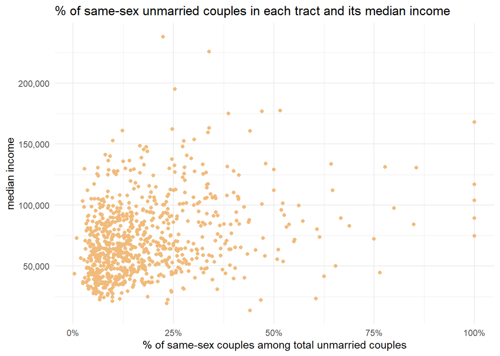

```r
filtered_ss_exist <- LA_tracts %>% filter(samesex_hh_exist == TRUE)

ggplot(filtered_ss_exist, aes(pct_samesex_hh, med_income, color = ""))+
  geom_point()+
  labs(title = "% of same-sex unmarried couples in each tract and its median income",
       x = "% of same-sex couples among total unmarried couples",
       y = "median income")+
  scale_x_continuous(labels = percent)+
  scale_y_continuous(labels = comma)+
  theme_minimal()+
  theme(legend.position = 'none')+
  scale_color_manual(values = wes_palette(n=1, "GrandBudapest1"))
```

## Plot #5

### Heatmap of the percent of renting households in each tract divided into categories of the tract reporting same-sex unmarried couples and the tract median income being over $50,000.

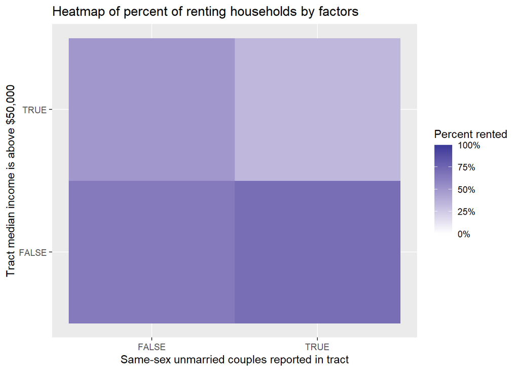

```r
ggplot(LA_tracts %>% filter (tot_housing > 0),
       aes(x = samesex_hh_exist, y = inc_abo_50, fill = (pct_rented))) +
  geom_tile()+
  labs(title = "Heatmap of percent of renting households by factors",
       x = "Same-sex unmarried couples reported in tract",
       y = "Tract median income is above $50,000")+
   scale_fill_gradient2(name = "Percent rented", labels = percent)
```

## Plot #6

### Scatterplot of the median income and % of renting households in each tract.

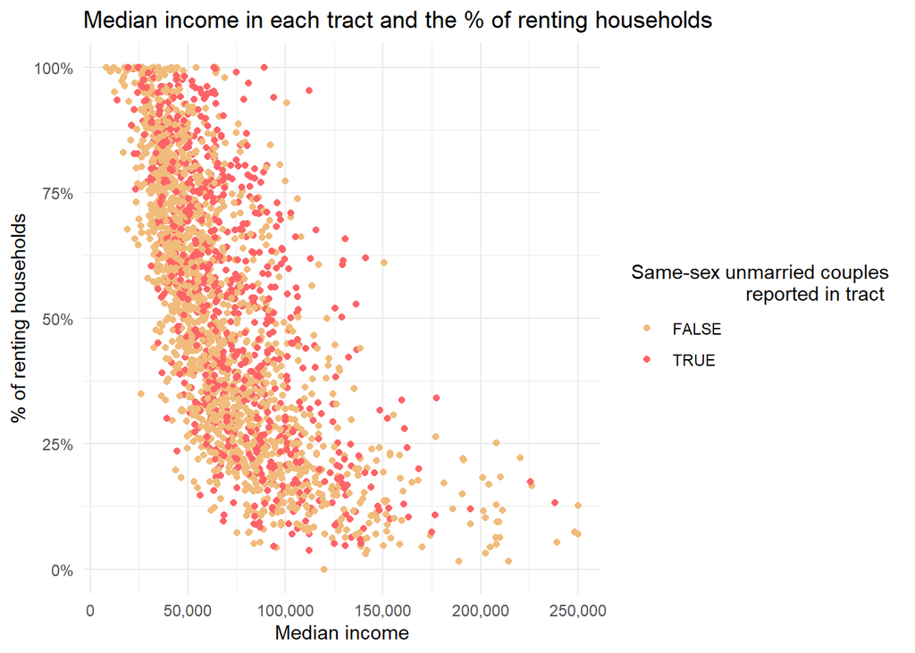

```r
ggplot(LA_tracts %>% drop_na(med_income),
       aes(x = med_income, y = pct_rented, color = samesex_hh_exist)) +
  geom_point()+
  labs(title = "Median income in each tract and the % of renting households",
       x = "Median income",
       y = "% of renting households")+
  scale_x_continuous(labels = comma)+
  scale_y_continuous(labels = percent)+
  theme_minimal()+
  scale_color_manual(name = "Same-sex unmarried couples
                     reported in tract",
                     values = wes_palette("GrandBudapest1"))
```

## Plot #7

### Chart of the count of households by education attainment. Divided into whether same-sex unmarried couples were reported in tract.

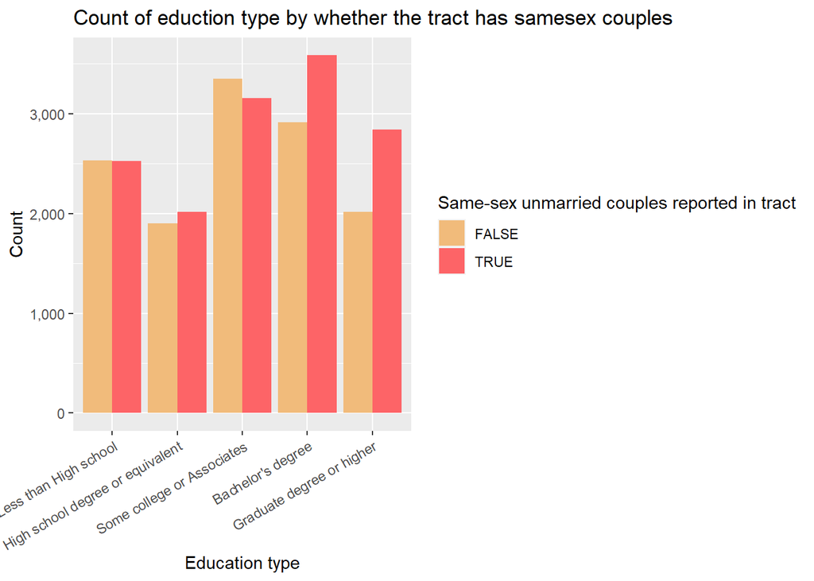

```r
edu_pivot <- LA_tracts %>%
                pivot_longer(
                  c( edu_less_hs, edu_hs, edu_some_college, edu_bach, edu_grad),
                  names_to = "edu_type", values_to = "edu_count")
edu_pivot$edu_type <- factor(edu_pivot$edu_type,
                             levels = c("edu_less_hs", "edu_hs",
                                        "edu_some_college", "edu_bach",
                                        "edu_grad"))

ggplot(edu_pivot, aes(x = edu_type, y = edu_count, fill = samesex_hh_exist)) +
  geom_col( position = position_dodge())+
  labs(title = "Count of eduction type by whether the tract has samesex couples",
       x = "Education type", y = "Count")+
  scale_x_discrete(labels = c("edu_bach" = "Bachelor's degree",
                     "edu_grad" = "Graduate degree or higher",
                     "edu_hs" = "High school degree or equivalent",
                     "edu_less_hs" = "Less than High school",
                     "edu_some_college" = "Some college or Associates"))+
  scale_y_continuous(labels = comma)+
  scale_fill_manual(name = "Same-sex unmarried couples reported in tract",
                    values = wes_palette("GrandBudapest1"))+
  theme(axis.text.x = element_text(angle = 30, hjust = 1))
```

## Plot #8

### Scatterplot of the % of households with less than a high school degree and the median income of each tract

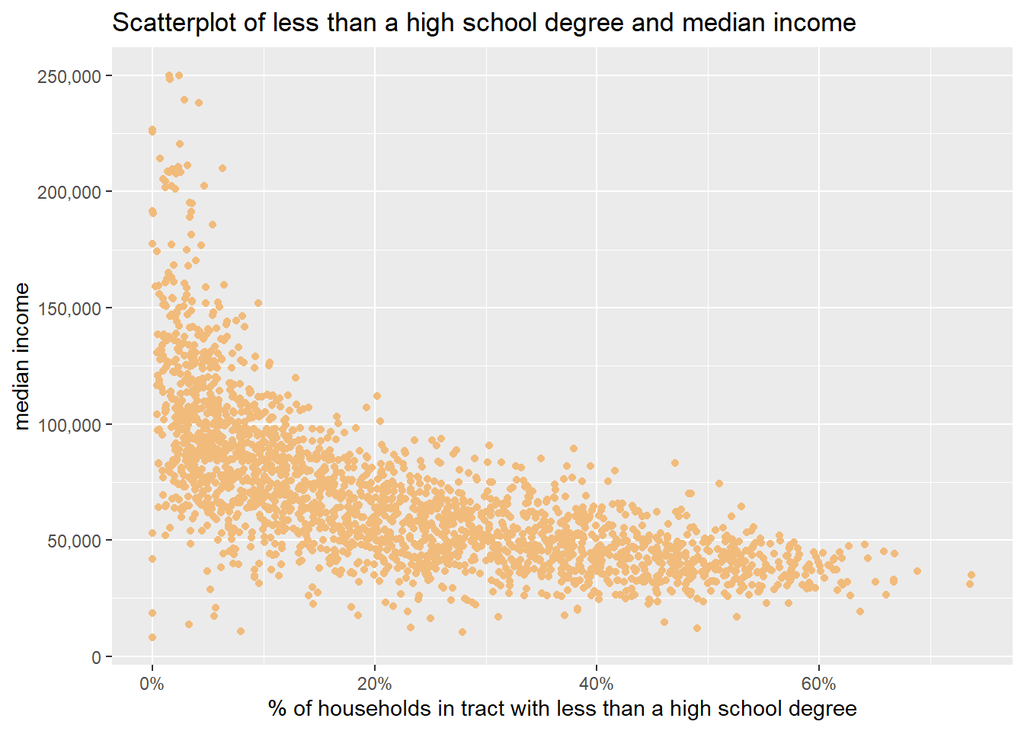

```r
ggplot(LA_tracts %>% drop_na(med_income),
            aes(x = pct_edu_less_hs, y = med_income, color = "")) +
  geom_point()+
  labs(title = "Scatterplot of less than a high school degree and median income",
       x = "% of households in tract with less than a high school degree",
       y = "median income")+
  scale_x_continuous(labels = percent)+
  scale_y_continuous(labels = comma)+
  theme(legend.position = 'none')+
  scale_color_manual(values = wes_palette("GrandBudapest1"))
```

## Plot #9

### Density plot of the precentages in each tract of households with less than a high school degree.

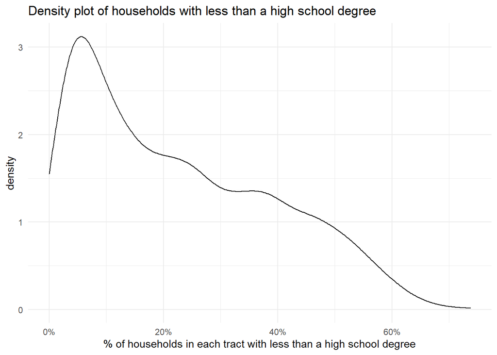

```r
ggplot(LA_tracts, aes(pct_edu_less_hs))+
  geom_density() +
  labs(title = "Density plot of households with less than a high school degree",
    x = "% of households in each tract with less than a high school degree" )+
  scale_x_continuous(labels = percent)+
  theme_minimal()
```

## Plot #10

### Boxplot of the precentages in each tract of households with less than a high school degree divided by whether same-sex unmarried couples were reported in the tract.

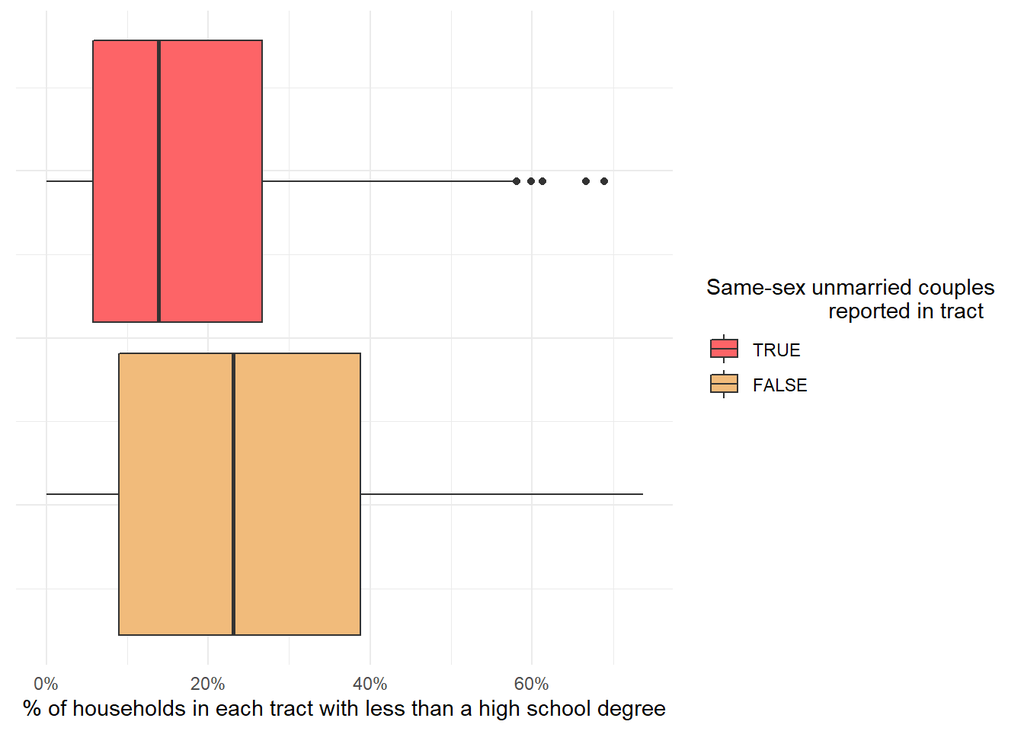

```r
ggplot(LA_tracts, aes(x = pct_edu_less_hs, fill = samesex_hh_exist))+
  geom_boxplot()+
  labs(x = "% of households in each tract with less than a high school degree")+
  scale_x_continuous(labels = percent)+
  theme_minimal()+
  theme(axis.text.y = element_blank())+
  scale_fill_manual(name = "Same-sex unmarried couples
                    reported in tract",
                    values = wes_palette("GrandBudapest1"),
                    guide = guide_legend(reverse = TRUE))
```